# How to work with data from the GESIS AppKit

Charlotte de Alwis

Maximilian Haag

Julian Kohne

2026-09-23

# 1 Purpose of this notebook

This notebook is intended to make you familiar with processing and analyzing smartphone survey data collected with the GESIS AppKit in `R`, using the [`appkitr`](https://gitlab.com/gesis-appkit/appkitr) package where appropriate. It uses synthetic example data modeled after a real survey conducted with the GESIS AppKit on emotionality in social interactions.

The main goal of this notebook is to make the user familiar with the `R` package [`appkitr`](https://gitlab.com/gesis-appkit/appkitr) to read exported surveys, inspect them and to calculate participation rates and payout. The notebook also includes additional code for some further basic calculations and visualizations.

You can find more information on the GESIS AppKit on the [GESIS AppKit website](http://appkit.gesis.org/). To request your own account, register [here](https://admin.appkit.gesis.org/login).

# 2 Background

The demo study in this notebook is based on a [preregistered study](https://osf.io/q5maf) consisting of two parts. Part I intends to replicate the findings of the study by [Barrett et al. (1998)](https://doi.org/10.1080/026999398379565), which looks at self-reported emotionality in interactions and differences by gender, using an ESM design. The study’s main finding is:

*“We predicted and found that sex-related differences in emotion in global self-descriptions, but not in the averaged momentary ratings of emotion.” [Barrett et al. (1998)](https://doi.org/10.1080/026999398379565)*

Part II is an ESM design experiment: participants were randomly assigned to one of five groups that differ in agency over the scheduling of the prompts (choice-based vs. assigned) and in the number of daily prompts (3 vs. 5), plus a control group that receives no momentary assessments.

The study consisted of the following surveys:

- An entry survey distributed to participants after they logged into the study on the GESIS Smart app.
- A momentary assessment survey that was sent to participants 3 or 5 times during the day for a period of 4 days, plus a short evening survey each day.
- An exit survey that was distributed to participants after the momentary assessment period.

Participants were compensated per completed survey, which we will use later to calculate payouts.

**Note:** this notebook uses synthetic data for demonstration purposes. Therefore, this script can not be used to assess these research aims. Note that the synthetic data also does not reflect the ESM design experiment described above.

# 3 Setup

## 3.1 Install and load packages

In order to run the code in this notebook, you need to install and load the following packages. The [`appkitr`](https://gitlab.com/gesis-appkit/appkitr) package is not yet available on CRAN, so we install it from GitLab using the `remotes` package:

```r
# List of required packages
packages <- c("ggplot2",
              "dplyr",
              "psych",
              "tidyverse",
              "scales"
              )

installed_packages <- packages %in% rownames(installed.packages())

# Then install missing packages
if (any(installed_packages == FALSE)) {
  install.packages(packages[!installed_packages])
}

# Then load all packages
invisible(lapply(packages, library, character.only = TRUE))
```

```r
# appkitr is not on CRAN yet: install the latest release from GitLab
if (!require("appkitr", quietly = TRUE)) {
install.packages("remotes")
remotes::install_gitlab("gesis-appkit/appkitr")
library(appkitr)
}
```

## 3.2 Import data

The [`appkitr`](https://gitlab.com/gesis-appkit/appkitr) package includes functions to read survey exports from the GESIS AppKit which take care of the formatting for you. An export consists of a `.csv` file with the responses and an `.sps` (SPSS syntax) file with the variable and value labels. `read_appkit_survey()` reads one such survey from a directory, converts timestamps and logical variables, sets specified values (by default `-1`, empty strings, `"Not applicable"` and `"N/A"`) to `NA`, and attaches the labels from the `.sps` file.

To try this out, the `data/example_survey` folder contains one small example survey:

```r
survey <- read_appkit_survey("data/example_survey")
```

Real studies usually consist of several surveys (e.g. an entry survey, momentary assessments and an exit survey). With `read_appkit_surveys()` you can read all surveys from a parent directory at once, where each subfolder contains one survey. The result is a named list with one data frame per survey:

```r
surveys_example <- read_appkit_surveys("data/example_surveys")
names(surveys_example)
```

```
## [1] "survey_name_1" "survey_name_2"
```

If you use different missing value codes, you can change them with the `na_values` argument, e.g. `read_appkit_surveys("data/example_surveys", na_values = c(-1, -99))`.

```r
?read_appkit_survey
```

For the rest of this demo, we use the synthetic example data that comes with `appkitr`.

It is based on the study described in the introduction. Let’s have a look at the documentation for `appkit_survey_entry`:

```r
?appkit_survey_entry
```

In addition to an entry survey, the package contains a momentary assessment survey and an exit survey:

```r
entry <- appkit_survey_entry
esm <- appkit_survey_esm
exit <- appkit_survey_exit
```

Let’s inspect each of the surveys in turn. We will start with the entry survey.

# 4 Entry Survey

## 4.1 Exploration

Let’s have a first look:

```r
glimpse(entry)
```

```
## Rows: 20
## Columns: 40
## $ personalParticipantCode <chr> "n8cyhsut", "sm6tkhcu", "k8xjbxij", "5islfg00"…
## $ generalLoginCode        <chr> "STUDYEMOTIONS", "STUDYEMOTIONS", "STUDYEMOTIO…
## $ status                  <chr> "ACTIVE", "ACTIVE", "ACTIVE", "ACTIVE", "ACTIV…
## $ lastStatusChange        <dttm> NA, NA, NA, NA, NA, NA, NA, NA, NA, NA, NA, N…
## $ note                    <lgl> NA, NA, NA, NA, NA, NA, NA, NA, NA, NA, NA, NA…
## $ firstOpened             <dttm> 2026-04-01 13:25:00, 2026-04-01 14:38:00, 202…
## $ committed               <dttm> 2026-04-01 13:28:00, 2026-04-01 14:42:00, 202…
## $ scheduled               <dttm> 2026-04-01 08:00:00, 2026-04-01 08:00:00, 202…
## $ expired                 <dttm> 2026-04-01 23:59:00, 2026-04-01 23:59:00, 202…
## $ published               <dttm> 2026-03-31 10:55:22, 2026-03-31 10:55:22, 202…
## $ exported                <dttm> 2026-05-01 17:08:10, 2026-05-01 17:08:10, 202…
## $ osVersion               <chr> "Android 13", "Android 13", "iOS 18.6.2", "And…
## $ smartphoneType          <chr> "SM-S928B", "SM-A356B", "iPhone11,8", "Pixel 8…
```

[output cut: 27 more lines]

We can see that the entry survey contains 20 rows and 40 columns. This indicates that there are 20 participants and 40 variables in the entry survey. 17 of the variables contain metadata about the survey and the participant, where the other 23 variables contain the survey items defined by the researcher.

The first 17 variables contain metadata on the participant and their device, e.g.:

- `personalParticipantCode` Used to identify the participant in the study.
- `generalLoginCode` Stores the general login code.
- `status` Participant Status (active, deactivated, deleted).
- `lastStatusChange` Timestamp indicating last change of `status`.
- `note` Field for an optional researcher note in the participant monitoring table.
- `firstOpened` Timestamp indicating when the survey was first opened.
- `committed` Timestamp indicating when the participant’s response was committed.
- `scheduled` Timestamp indicating when the survey was scheduled for the participant.
- `expired` Timestamp indicating when the survey expired (if an expiration time was set).
- `published` Timestamp indicating when the survey was set to published in the GESIS AppKit backend.
- `exported` Timestamp indicating when the survey was exported.
- `osVersion` Holds information about the participant’s operating system version.
- `smartphoneType` Holds information about the participant’s smartphone or device type
- `pushNotificationAllowed` Logical to capture whether push notifications were allowed or not.
- `notificationType` Type of the push notification (default vs. custom).
- `notificationTitle` Title of the push notification.
- `notificationText` Text of the push notification.

The variable labels are stored as attributes and the value labels as factor levels. Let’s have a look at one exemplary variable:

```r
# variable label
attr(entry$aim01, "label")
```

```
## [1] "When I feel happiness, it is a quiet type of contentment."
```

```r
# value labels
levels(entry$aim01)
```

```
## [1] "Never"         "Almost never"  "Occasionally"  "Usually"
## [5] "Almost always" "Always"
```

We can also use the `inspect_variable()` function from `appkitr`:

```r
inspect_variable(entry$aim01)
```

| var_name | var_type | var_label | unique_values | value_labels |
| --- | --- | --- | --- | --- |
| entry$aim01 | factor | When I feel happiness, it is a quiet type of contentment. | Occasionally, Usually, Almost always, Never, Alway... | 1 = Never, 2 = Almost never, 3 = Occasionally, 4 =... |

To have a look at all the variables in a survey, use `inspect_variables()`:

```r
inspect_variables(entry)
```

```
##
## ── Variable Inspector ──────────────────────────────────────────────────────────
##
## personalParticipantCode (character): PersonalParticipantCode
##   Unique values:  n8cyhsut, sm6tkhcu, k8xjbxij, 5islfg00, sh28c8is, ...
##   Value labels:  <none>
## ────────────────────────────────────────────────────────────────────────────────
## generalLoginCode (character): GeneralLoginCode
##   Unique values:  STUDYEMOTIONS
##   Value labels:  <none>
## ────────────────────────────────────────────────────────────────────────────────
## status (character): Participant Status
##   Unique values:  ACTIVE
##   Value labels:  <none>
## ────────────────────────────────────────────────────────────────────────────────
## lastStatusChange (POSIXct): Last Status Change
##   Unique values:
##   Value labels:  <none>
## ────────────────────────────────────────────────────────────────────────────────
## note (logical): Note
##   Unique values:
##   Value labels:  <none>
## ────────────────────────────────────────────────────────────────────────────────
## firstOpened (POSIXct): First Opened
##   Unique values:  2026-04-01 13:25:00, 2026-04-01 14:38:00, 2026-04-...
##   Value labels:  <none>
## ────────────────────────────────────────────────────────────────────────────────
## committed (POSIXct): Committed
##   Unique values:  2026-04-01 13:28:00, 2026-04-01 14:42:00, 2026-04-...
##   Value labels:  <none>
## ────────────────────────────────────────────────────────────────────────────────
## scheduled (POSIXct): Scheduled
##   Unique values:  2026-04-01 08:00:00
##   Value labels:  <none>
## ────────────────────────────────────────────────────────────────────────────────
## expired (POSIXct): Expired
##   Unique values:  2026-04-01 23:59:00
##   Value labels:  <none>
## ────────────────────────────────────────────────────────────────────────────────
## published (POSIXct): Published
```

[output cut: 109 more lines]

```
##   Value labels:  1 = Never, 2 = Almost never, 3 = Occasionally, 4 =...
## ────────────────────────────────────────────────────────────────────────────────
## aim18 (factor): I get overly enthusiastic.
##   Unique values:  Always, Usually, Almost never, Occasionally, Never...
##   Value labels:  1 = Never, 2 = Almost never, 3 = Occasionally, 4 =...
## ────────────────────────────────────────────────────────────────────────────────
## aim19 (factor): My happy moods are so strong that I feel like I'm 'in heaven'.
##   Unique values:  Never, Always, Almost never, Almost always, Occasi...
##   Value labels:  1 = Never, 2 = Almost never, 3 = Occasionally, 4 =...
## ────────────────────────────────────────────────────────────────────────────────
## aim20 (factor): When something bad happens, others tend to be more unhappy than I.
##   Unique values:  Occasionally, Usually, Almost never, Almost always...
##   Value labels:  1 = Never, 2 = Almost never, 3 = Occasionally, 4 =...
##
##  ────────────────────────────────────────────────────────────────────────────────
```

## 4.2 Demographics

Now let’s look at some demographics:

```r
# participant gender
table(entry$gender, useNA = "always")
```

```
##
##                           Female                             Male
##                                5                               13
## Another gender (e.g. non-binary)                             <NA>
##                                0                                2
```

How old are our participants? Let’s take a look at the age distribution.

```r
summary(entry$age)
```

```
##    Min. 1st Qu.  Median    Mean 3rd Qu.    Max.    NA's
##   18.00   32.00   40.50   42.17   55.25   65.00       2
```

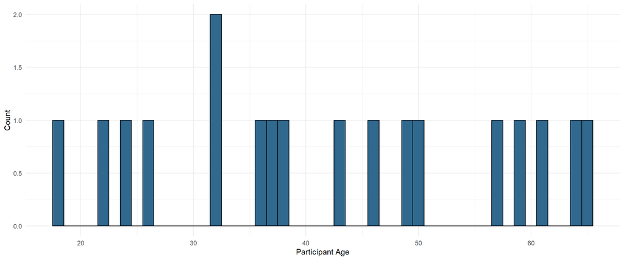

Figure 1. Participant Age Distribution

```r
# histogram
ggplot(entry, aes(x = age)) +
  geom_histogram(binwidth = 1, color = "black", fill = "#31688E") +
  labs(x = "Participant Age",
       y = "Count") +
  theme_minimal()
```

## 4.3 Affect Intensity Measure (AIM)

In the entry survey, we are administering the 20-item version of the [Affect Intensity Measure (AIM)](https://labs.psychology.illinois.edu/~ediener/AIM.html). The AIM scale is a self-report measure of the intensity of emotional experience. Participants are asked to rate the intensity of their emotional experience on a 6-point Likert-scale ranging from 1 (never) to 6 (always). The AIM scale consists of 20 items, the 10 items representing low emotional intensity are reverse-coded. So let’s check which questions need to be reverse coded.

```r
# print question labels of AIM items
# Extract aim data (the items aim01 to aim20)
aim_data <- entry %>% select(matches("^aim[0-9]{2}$"))

sapply(aim_data, function(x) attr(x, "label"))
```

```
##                                                                                             aim01
##                                       "When I feel happiness, it is a quiet type of contentment."
##                                                                                             aim02
##         "When a person in a wheelchair can't get through a door, I have strong feelings of pity."
##                                                                                             aim03
##                                                                             "I get upset easily."
##                                                                                             aim04
##                                   "When I succeed at something, my reaction is calm contentment."
##                                                                                             aim05
##                                                           "I get really happy or really unhappy."
##                                                                                             aim06
##                                                                     "I am a fairly quiet person."
##                                                                                             aim07
##                                                        "When I'm happy, I feel fairly energetic."
##                                                                                             aim08
##  "Seeing a picture of some violent car accident in a newspaper makes me feel sick to my stomach."
##                                                                                             aim09
##                                              "When I'm happy, I feel like I'm bursting with joy."
##                                                                                             aim10
##                                               "I would be very upset, if I got a traffic ticket."
##                                                                                             aim11
##                                     "Looking at beautiful scenery really doesn't affect me much."
##                                                                                             aim12
##                                                             "The weather doesn't affect my mood."
##                                                                                             aim13
##                                                      "Others tend to get more excited than I do."
##                                                                                             aim14
##                                                  "I am not an extremely enthusiastic individual."
##                                                                                             aim15
##                                                         "Calm and cool could easily describe me."
##                                                                                             aim16
## "When I'm feeling well it is easy for me to go from being in a good mood to being really joyful."
##                                                                                             aim17
##                                                 "When I worry, it is so mild I hardly notice it."
##                                                                                             aim18
##                                                                      "I get overly enthusiastic."
##                                                                                             aim19
##                                  "My happy moods are so strong that I feel like I'm 'in heaven'."
##                                                                                             aim20
##                              "When something bad happens, others tend to be more unhappy than I."
```

As we can see from the labels above, we need to reverse code the following items: `1, 4, 6, 11, 12, 13, 14, 15, 17, 20`. Let’s take a look at the data again for these variables and recode them

```r
# get rid of the labels, keep only numeric values
aim_data <- sapply(aim_data,as.numeric)

# reverse-coding items (columns 1,4,6,11,12,13,14,15,17,20)
reverse_items <- c(1, 4, 6, 11, 12, 13, 14, 15, 17, 20)

# Reverse code the specified items in a loop
for (item in reverse_items) {
  aim_data[, item] <- reverse.code(items = aim_data[, item], keys= -1, mini = 1, maxi = 6)
}
```

Now that we have reverse-coded the correct items, we can calculate the overall mean score for the AIM scale.

```r
# summary scores
aim_score <- rowSums(aim_data)/20

# attaching to dataframe
entry$aim_score <- aim_score
```

Let’s take a look at the overall AIM score.

```r
# summary of AIM score
summary(entry$aim_score)
```

```
##    Min. 1st Qu.  Median    Mean 3rd Qu.    Max.    NA's
##   2.500   3.263   3.350   3.350   3.475   3.950       2
```

Now let’s have a look at aim by gender:

```r
# Aim score by gender
by(entry$aim_score, entry$gender, summary)
```

```
## entry$gender: Female
##    Min. 1st Qu.  Median    Mean 3rd Qu.    Max.
##    3.20    3.30    3.35    3.43    3.35    3.95
## ------------------------------------------------------------
## entry$gender: Male
##    Min. 1st Qu.  Median    Mean 3rd Qu.    Max.
##   2.500   3.250   3.350   3.319   3.500   3.650
## ------------------------------------------------------------
## entry$gender: Another gender (e.g. non-binary)
## NULL
```

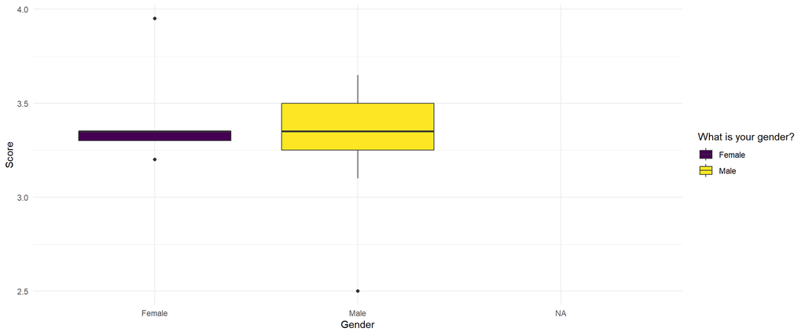

Figure 2. Side-by-Side Boxplot of Aim Score by Gender

```r
ggplot(entry, aes(x = gender, y = aim_score, fill = gender)) +
  geom_boxplot() +
  labs(x = "Gender",
       y = "Score") +
  theme_minimal() +
  scale_fill_viridis_d()
```

# 5 Momentary Assessment Survey

## 5.1 Exploration

Let’s continue by examining the “main part” of our survey, the momentary assessment survey. We will start by looking at the variables contained in the survey. For this we will use the `inspect_variables()` function again.

```r
inspect_variables(esm)
```

```
##
## ── Variable Inspector ──────────────────────────────────────────────────────────
##
## personalParticipantCode (character): PersonalParticipantCode
##   Unique values:  n8cyhsut, sm6tkhcu, k8xjbxij, 5islfg00, sh28c8is, ...
##   Value labels:  <none>
## ────────────────────────────────────────────────────────────────────────────────
## generalLoginCode (character): GeneralLoginCode
##   Unique values:  STUDYEMOTIONS
##   Value labels:  <none>
## ────────────────────────────────────────────────────────────────────────────────
## status (character): Participant Status
##   Unique values:  ACTIVE
##   Value labels:  <none>
## ────────────────────────────────────────────────────────────────────────────────
## lastStatusChange (POSIXct): Last Status Change
##   Unique values:
##   Value labels:  <none>
## ────────────────────────────────────────────────────────────────────────────────
## note (logical): Note
##   Unique values:
##   Value labels:  <none>
## ────────────────────────────────────────────────────────────────────────────────
## firstOpened (POSIXct): First Opened
##   Unique values:  2026-04-02 08:57:00, 2026-04-02 12:42:00, 2026-04-...
##   Value labels:  <none>
## ────────────────────────────────────────────────────────────────────────────────
## committed (POSIXct): Committed
##   Unique values:  2026-04-02 09:02:00, 2026-04-02 12:44:00, 2026-04-...
##   Value labels:  <none>
## ────────────────────────────────────────────────────────────────────────────────
## scheduled (POSIXct): Scheduled
##   Unique values:  2026-04-02 08:41:00, 2026-04-02 12:35:00, 2026-04-...
##   Value labels:  <none>
## ────────────────────────────────────────────────────────────────────────────────
## expired (POSIXct): Expired
##   Unique values:  2026-04-02 09:41:00, 2026-04-02 13:35:00, 2026-04-...
##   Value labels:  <none>
## ────────────────────────────────────────────────────────────────────────────────
## published (POSIXct): Published
```

[output cut: 93 more lines]

```
##   Value labels:  <none>
## ────────────────────────────────────────────────────────────────────────────────
## emo_embarrassed (integer): Please indicate how embarrassed you felt during the interaction.
##   Unique values:  5, 6, 2, 4, 1, 3, 7
##   Value labels:  <none>
## ────────────────────────────────────────────────────────────────────────────────
## emo_ashamed (integer): Please indicate how ashamed you felt during the interaction.
##   Unique values:  7, 3, 4, 5, 1, 2, 6
##   Value labels:  <none>
## ────────────────────────────────────────────────────────────────────────────────
## dataquality (factor): Thank you very much for supporting our research. For ensuring data quality, please indicate whether you answered the questions within this survey conscientiously:
##   Unique values:  I have answered the questions conscientiously, I d...
##   Value labels:  1 = I have answered the questions conscientiously,...
##
##  ────────────────────────────────────────────────────────────────────────────────
```

## 5.2 Participation

As you can see, participants were asked about their interactions with others throughout the day and how they felt about them. You can also see that the data structure is different from the entry survey. While the entry dataframe had one row per participant, the momentary assessment dataframe has multiple rows per participant. Let’s check this:

```r
table(esm$personalParticipantCode, useNA = "always")
```

```
##
## 2ypoflt2 350f38rb 4yrk9gco 5islfg00 7hs1ynnz 7rspufqi 9ld5s7af b876dqk5
##        9        9        9        9        9        9        9        9
## ci862jvm hnsh4r2w ic4qttj3 iityqz6r k8xjbxij kizmrjkh n8cyhsut p5e65m1e
##        9        9        9        9        9        9        9        9
## q5vq3je8 sh28c8is sm6tkhcu u6n4xik4     <NA>
##        9        9        9        9        0
```

Or simply use the `participation_table` from the `appkitr` package:

```r
?participation_table
```

```r
participation_table(esm)
```

| personalParticipantCode | esm |
| --- | --- |
| n8cyhsut | 6 |
| sm6tkhcu | 4 |
| k8xjbxij | 4 |
| 5islfg00 | 6 |
| sh28c8is | 2 |
| 4yrk9gco | 6 |
| p5e65m1e | 8 |
| ic4qttj3 | 7 |
| iityqz6r | 8 |
| hnsh4r2w | 0 |

[output cut: 10 more lines]

```r
participation_table(esm, value = "percentage")
```

| personalParticipantCode | esm |
| --- | --- |
| n8cyhsut | 66.7 |
| sm6tkhcu | 44.4 |
| k8xjbxij | 44.4 |
| 5islfg00 | 66.7 |
| sh28c8is | 22.2 |
| 4yrk9gco | 66.7 |
| p5e65m1e | 88.9 |
| ic4qttj3 | 77.8 |
| iityqz6r | 88.9 |
| hnsh4r2w | 0.0 |

[output cut: 10 more lines]

Let’s check when the surveys were sent and how long it took participants to respond.

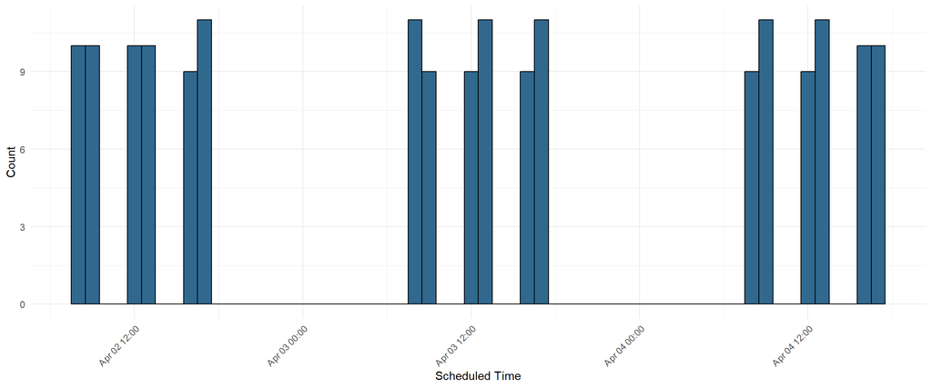

Figure 3. Distribution of Scheduled Beeps

```r
# Create a histogram of the scheduled times
ggplot(esm, aes(x = scheduled)) +
  geom_histogram(binwidth = 3600, fill = "#31688E", color = "black") +
  labs(x = "Scheduled Time",
       y = "Count") +
  theme_minimal() +
  theme(axis.text.x = element_text(angle = 45, hjust = 1))
```

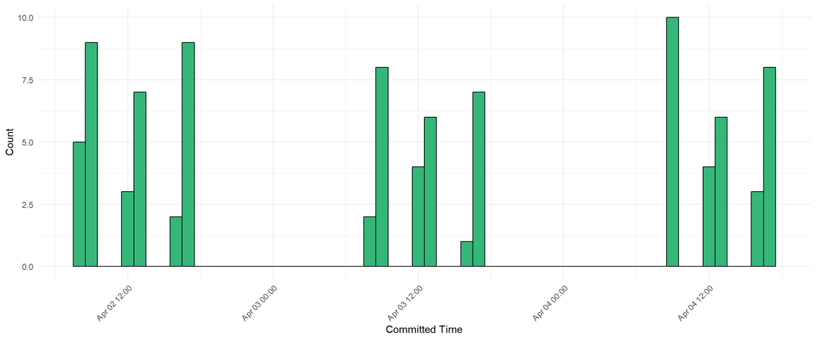

Figure 4. Distribution of Committed Beeps

```r
# Create a histogram of the committed times
ggplot(esm, aes(x = committed)) +
  geom_histogram(binwidth = 3600, fill = "#35B779", color = "black") +
  labs(x = "Committed Time",
       y = "Count") +
  theme_minimal() +
  theme(axis.text.x = element_text(angle = 45, hjust = 1))
```

Seems like the distribution of scheduled and committed times is fairly similar, but we can’t really tell from these plots, maybe we need a more advanced graphical representation.

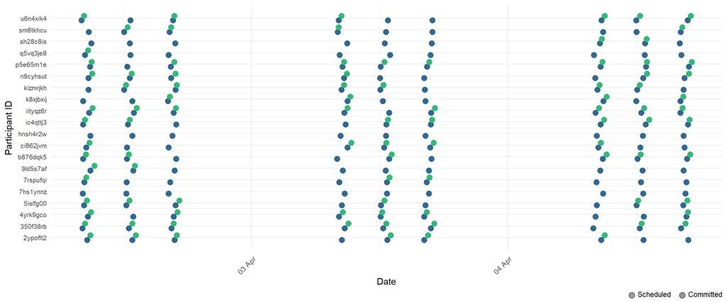

Figure 5. Scheduled and Committed Beeps per Participant

```r
# Define a small vertical offset.
offset <- 0.2

# create plot
esm %>%
  mutate(
    personalParticipantCode = factor(personalParticipantCode),
    ppt_index = as.numeric(personalParticipantCode)
  ) %>%
  distinct(personalParticipantCode, ppt_index) -> ppt_map

esm %>%
  mutate(
    personalParticipantCode = factor(personalParticipantCode),
    ppt_index = as.numeric(personalParticipantCode)
  ) %>%
  ggplot() +
  geom_segment(aes(
    x = scheduled, xend = committed,
    y = ppt_index - offset, yend = ppt_index + offset
  ), color = "grey", linewidth = 1) +
  geom_point(aes(x = scheduled, y = ppt_index - offset),
             color = "#31688E", size = 3) +
  geom_point(aes(x = committed, y = ppt_index + offset),
             color = "#35B779", size = 3) +
  scale_y_continuous(
    breaks = ppt_map$ppt_index,
    labels = ppt_map$personalParticipantCode
  ) +
  scale_x_datetime(
    date_breaks = "1 day",
    date_labels = "%d %b"
  ) +
  labs(
    x = "Date",
    y = "Participant ID",
    caption = "\U1F535 Scheduled    \U1F7E2 Committed"
  ) +
  theme_minimal() +
  theme(
    axis.text.x = element_text(angle = 45, hjust = 1),
    axis.text.y = element_text(size = 8)
  )
```

We can also calculate time between the scheduled and committed times. This will give us a pretty good idea of how long it took participants to respond to the surveys on average.

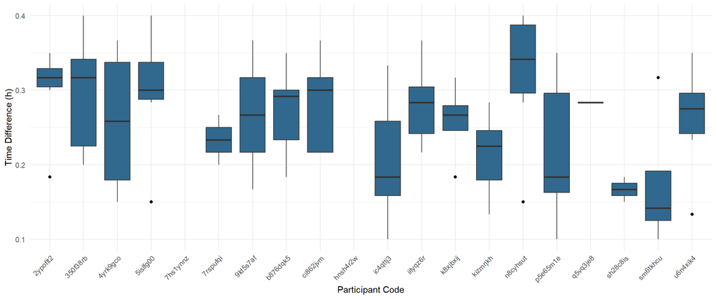

Figure 6. Time Lag Distributions per Participant

```r
# Calculate the time difference in seconds
esm <- esm %>%
  mutate(
    time_diff = as.numeric(difftime(committed, scheduled, units = "secs"))
  )

esm %>%
        mutate(time_diff_min = time_diff / 60) %>%
        mutate(time_diff_hours = time_diff_min / 60) %>%
  ggplot(aes(x = personalParticipantCode, y = time_diff_hours)) +
  geom_boxplot(fill = "#31688E", outlier.color = "black") +
  labs(
    x = "Participant Code",
    y = "Time Difference (h)"
  ) +
  theme_minimal() +
  theme(axis.text.x = element_text(angle = 45, hjust = 1))
```

On average, it took participants 0.26 hours to respond to the surveys. The median time difference is 0.28 hours. The maximum time difference is 0.4 hours and the fastest response time was 360 seconds.

## 5.3 Remove unsuitable observations

First, let’s reduce the dataframe to the instances where people actually reported on a social interaction.

```r
# subset dataframe to only include interactions
esm_interaction <- esm %>%
  filter(screening == TRUE)
```

Some participants indicated that they did not answer the questions conscientiously, so let’s remove these answers from the dataset, as we are only interested in the conscientious responses.

```r
# How many beeps were answered conscientiously
table(esm_interaction$dataquality)
```

```
##
##                                                      I have answered the questions conscientiously
##                                                                                                 60
## I did not answer the questions conscientiously (since I only want to get to know the GESIS AppKit)
##                                                                                                 10
```

```r
# remove non-conscientious answers
esm_interaction <- esm_interaction[esm_interaction$dataquality == "I have answered the questions conscientiously",]
```

## 5.4 Interactions

Let’s first have a look at what kind of interactions participants report on with respect to group sizes and interaction partner gender.

```r
# partner gender
table(esm_interaction$partner_gender)
```

```
##
##     Female       Male Non-binary      Other
##         27         29          2          2
```

```r
table(esm_interaction$personalParticipantCode, esm_interaction$partner_gender)
```

```
##
##            Female Male Non-binary Other
##   2ypoflt2      2    3          0     0
##   350f38rb      4    2          0     0
##   4yrk9gco      1    2          1     0
##   5islfg00      3    2          0     0
##   7rspufqi      2    1          0     0
##   b876dqk5      3    2          0     1
##   ci862jvm      3    0          0     0
##   ic4qttj3      1    3          0     0
##   iityqz6r      0    4          0     1
##   k8xjbxij      1    1          0     0
##   kizmrjkh      0    1          0     0
##   n8cyhsut      2    2          0     0
##   p5e65m1e      1    2          0     0
##   q5vq3je8      1    0          0     0
##   sh28c8is      0    2          0     0
##   sm6tkhcu      2    0          0     0
##   u6n4xik4      1    2          1     0
```

```r
round(prop.table(table(esm_interaction$personalParticipantCode, esm_interaction$partner_gender),margin = 1),2)
```

```
##
##            Female Male Non-binary Other
##   2ypoflt2   0.40 0.60       0.00  0.00
##   350f38rb   0.67 0.33       0.00  0.00
##   4yrk9gco   0.25 0.50       0.25  0.00
##   5islfg00   0.60 0.40       0.00  0.00
##   7rspufqi   0.67 0.33       0.00  0.00
##   b876dqk5   0.50 0.33       0.00  0.17
##   ci862jvm   1.00 0.00       0.00  0.00
##   ic4qttj3   0.25 0.75       0.00  0.00
##   iityqz6r   0.00 0.80       0.00  0.20
##   k8xjbxij   0.50 0.50       0.00  0.00
##   kizmrjkh   0.00 1.00       0.00  0.00
##   n8cyhsut   0.50 0.50       0.00  0.00
##   p5e65m1e   0.33 0.67       0.00  0.00
##   q5vq3je8   1.00 0.00       0.00  0.00
##   sh28c8is   0.00 1.00       0.00  0.00
##   sm6tkhcu   1.00 0.00       0.00  0.00
##   u6n4xik4   0.25 0.50       0.25  0.00
```

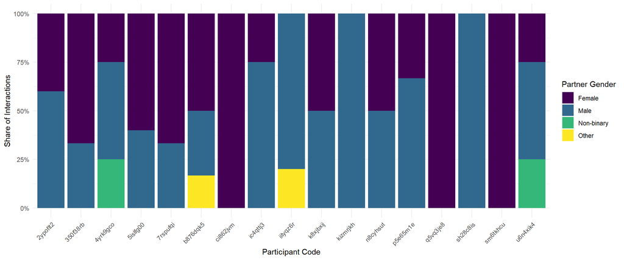

Figure 7. Share of Interaction Partner Gender by Participant

```r
# Proportional stacked bar per participant
ggplot(esm_interaction, aes(x = personalParticipantCode, fill = partner_gender)) +
  geom_bar(position = "fill") +
  labs(x = "Participant Code",
       y = "Share of Interactions",
       fill = "Partner Gender") +
  scale_fill_viridis_d() +
  scale_y_continuous(labels = scales::percent_format()) +
  theme_minimal() +
  theme(axis.text.x = element_text(angle = 45, hjust = 1))
```

```r
# join participant's own gender onto each interaction
esm_interaction <- esm_interaction %>%
  left_join(entry %>% select(personalParticipantCode, gender), by = "personalParticipantCode")

# harmonize own gender categories
esm_interaction <- esm_interaction %>%
  mutate(gender_own_grouped = case_when(
    as.character(gender) == "Female" ~ "Female",
    as.character(gender) == "Male" ~ "Male",
    as.character(gender) == "Another gender (e.g. non-binary)" ~ "Other/non-binary",
    TRUE ~ NA_character_
  ))

# harmonize partner gender categories
esm_interaction <- esm_interaction %>%
  mutate(partner_gender_grouped = case_when(
    as.character(partner_gender) == "Female" ~ "Female",
    as.character(partner_gender) == "Male" ~ "Male",
    as.character(partner_gender) %in% c("Non-binary", "Other") ~ "Other/non-binary",
    TRUE ~ NA_character_
  ))

# now compare on the harmonized categories
esm_interaction <- esm_interaction %>%
  mutate(gender_match = case_when(
    is.na(gender_own_grouped) | is.na(partner_gender_grouped) ~ NA_character_,
    gender_own_grouped == partner_gender_grouped ~ "same",
    TRUE ~ "different"
  ))
```

In total, participants reported on 60 interactions. Of these, 27 were with women, 29 with men, 2 with non-binary partners, and 2 with partners of another gender. Looking at how this compares to participants’ own gender, 30 interactions were with a partner of the same gender, while 22 were with a partner of a different gender.

```r
# Group size
summary(esm_interaction$groupsize, useNA = "never")
```

```
##    Min. 1st Qu.  Median    Mean 3rd Qu.    Max.
##    1.00    2.00    4.00    3.75    5.00    6.00
```

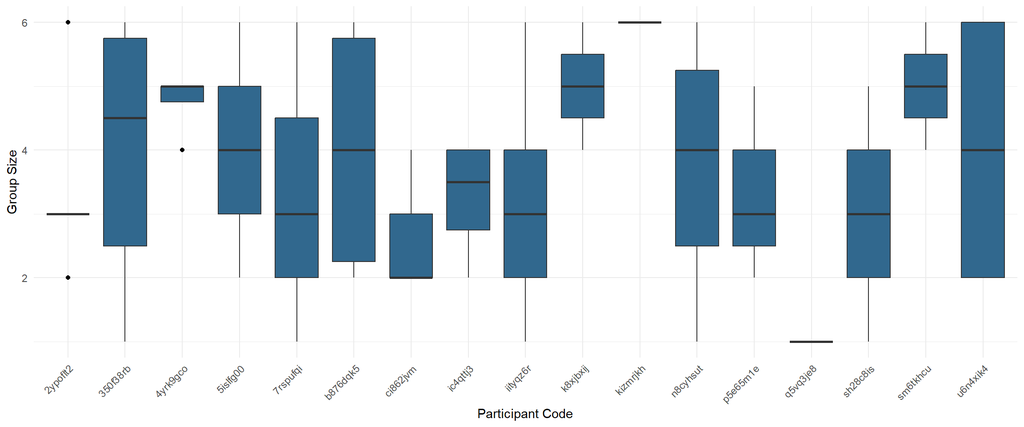

Figure 8. Group size Distributions per Participant

```r
esm_interaction %>%
  ggplot(aes(x = personalParticipantCode, y = groupsize)) +
  geom_boxplot(fill = "#31688E", outlier.color = "black") +
  labs(
    x = "Participant Code",
    y = "Group Size"
  ) +
  theme_minimal() +
  theme(axis.text.x = element_text(angle = 45, hjust = 1))
```

On average, participants reported interacting with 3.75 people per interaction (median: 4). Group sizes ranged from 1 to 6 people.

Let’s also check the reported duration of interactions.

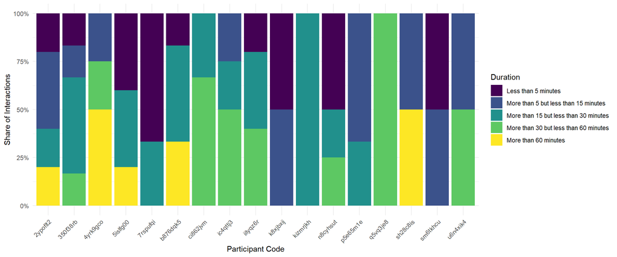

Figure 9. Share of Interaction Duration by Participant

```r
ggplot(esm_interaction, aes(x = personalParticipantCode, fill = duration)) +
  geom_bar(position = "fill") +
  labs(x = "Participant Code",
       y = "Share of Interactions",
       fill = "Duration") +
  scale_fill_viridis_d() +
  scale_y_continuous(labels = scales::percent_format()) +
  theme_minimal() +
  theme(axis.text.x = element_text(angle = 45, hjust = 1))
```

Across all 60 interactions, the most commonly reported duration was “More than 15 but less than 30 minutes”, accounting for 28.3% of interactions. The least common duration category was “More than 60 minutes” (11.7%).

## 5.5 Emotionality

Finally, let’s check the emotionality of reported social interactions!

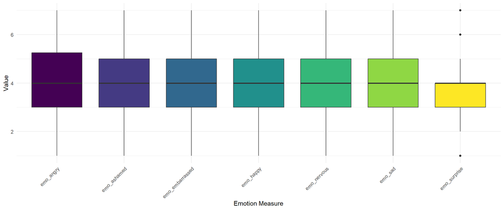

Figure 10. Distribution of Emotion Measures (All Participants)

```r
# Emotionality Features
summary_by_ppt <- esm_interaction %>%
  pivot_longer(
    cols = c(emo_happy,
             emo_sad,
             emo_nervous,
             emo_surprise,
             emo_angry,
             emo_embarrassed,
             emo_ashamed),
    names_to = "measure",
    values_to = "value"
  ) %>%
  group_by(personalParticipantCode, measure) %>%
  summarise(summary_stats = list(summary(value)), .groups = "drop") %>%
  unnest_wider(summary_stats)
#print(summary_by_ppt)

# All ppts
esm_interaction %>%
  pivot_longer(
    cols = c(emo_happy,
             emo_sad,
             emo_nervous,
             emo_surprise,
             emo_angry,
             emo_embarrassed,
             emo_ashamed),
    names_to = "measure",
    values_to = "value"
  ) %>%
  ggplot(aes(x = measure, y = value, fill = measure)) +
  geom_boxplot() +
  labs(x = "Emotion Measure",
       y = "Value") +
  theme_minimal() +
  scale_fill_viridis_d() +
  theme(legend.position = "none",
        axis.text.x = element_text(angle = 45, hjust = 1))
```

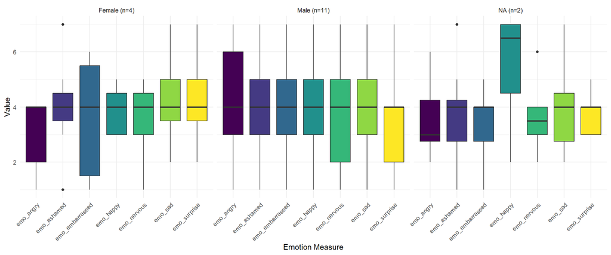

Figure 11. Distribution of Emotion Measures by Participant Gender

```r
esm_interaction %>%
  filter(gender_own_grouped %in% c("Female", "Male") | is.na(gender_own_grouped)) %>%
  mutate(gender_facet = ifelse(is.na(gender_own_grouped), "NA", gender_own_grouped)) %>%
  group_by(gender_facet) %>%
  mutate(gender_facet = paste0(gender_facet, " (n=", n_distinct(personalParticipantCode), ")")) %>%
  ungroup() %>%
  pivot_longer(
    cols = c(emo_happy,
             emo_sad,
             emo_nervous,
             emo_surprise,
             emo_angry,
             emo_embarrassed,
             emo_ashamed),
    names_to = "measure",
    values_to = "value"
  ) %>%
  ggplot(aes(x = measure, y = value, fill = measure)) +
  geom_boxplot() +
  facet_wrap(~ gender_facet) +
  labs(x = "Emotion Measure",
       y = "Value") +
  theme_minimal() +
  scale_fill_viridis_d() +
  theme(legend.position = "none",
        axis.text.x = element_text(angle = 45, hjust = 1))
```

# 6 Payout

The `appkitr` package also includes a function to calculate payout.

**Note:** `calculate_payout()` and `create_payout_scheme()` are calculation aids only, with no guarantee of correctness. Always manually verify payout amounts before making any actual payments.

You can either create your payout scheme manually or create the payout scheme in an interactive session:

```r
payout_scheme_manual <- data.frame(
  survey = c("entry", "esm", "esm"),
  type = c("per_questionnaire", "per_questionnaire", "threshold"),
  threshold_n = c(NA, NA, 5),
  amount = c(1.0, 0.5, 3.0)
)
payout_scheme_manual
```

| survey | type | threshold_n | amount |
| --- | --- | --- | --- |
| entry | per_questionnaire | NA | 1.0 |
| esm | per_questionnaire | NA | 0.5 |
| esm | threshold | 5 | 3.0 |

```r
if (interactive()) {
  if (!exists("payout_scheme_interactive")) {
    payout_scheme_interactive <- create_payout_scheme(list(entry = entry, esm = esm))
    print(payout_scheme_interactive)
  } else {
    print(payout_scheme_interactive)
  }
}
```

```r
calculate_payout(payout_scheme = payout_scheme_manual, data = list(entry=entry, esm=esm))
```

```
## calculate_payout() is a calculation aid only, with no guarantee of correctness. Always manually verify payout amounts before making any actual payments.
```

| personalParticipantCode | entry | esm | total |
| --- | --- | --- | --- |
| n8cyhsut | 1 | 6.0 | 7.0 |
| sm6tkhcu | 1 | 2.0 | 3.0 |
| k8xjbxij | 1 | 2.0 | 3.0 |
| 5islfg00 | 1 | 6.0 | 7.0 |
| sh28c8is | 1 | 1.0 | 2.0 |
| 4yrk9gco | 1 | 6.0 | 7.0 |
| p5e65m1e | 1 | 7.0 | 8.0 |
| ic4qttj3 | 1 | 6.5 | 7.5 |
| iityqz6r | 1 | 7.0 | 8.0 |
| hnsh4r2w | 1 | 0.0 | 1.0 |

[output cut: 10 more lines]

# 7 Further resources

You find detailed documentation on how to use the GESIS AppKit in the [manual](https://appkit.gesis.org/manual/) and on our [website](https://www.gesis.org/gesis-appkit).

**Lectures**

- Otto, L., & Wieland, M. (2024). *Meet the Experts: Einsatz von Smartphones zur Erforschung von intraindividuellen Prozessen und situativen Dynamiken*. [Video](https://www.youtube.com/watch?v=leKHSTJ5JxI); [Slides](https://www.gesis.org/fileadmin/admin/Dateikatalog/Veranstaltungen/MeetTheExperts/Meet_the_Experts_Wieland_Otto.pdf)

**Guides**

- Lux, V., & Wieland, M. (2025). *GESIS Guide to Digital Behavioral Data: Aufsetzen und Monitoring von App-basierten Datenerhebungen*. https://www.gesis.org/fileadmin/admin/Dateikatalog/pdf/guides/22_Lux_Wieland_App_Studies.pdf
- de Alwis, C., Lakshmi, V., & Wieland, M. (2026). *GESIS Guide to Digital Behavioral Data: How to use the GESIS AppKit*. https://www.gesis.org/fileadmin/admin/Dateikatalog/pdf/guides/27_de_Alwis_Lakshmi_Wieland_How_to_AppKit.pdf

**Publications**

- de Alwis, C., Haag, M., Kohne, J., Otto, L., Schnasse, J., & Wieland, M. (2026). *Introducing the GESIS AppKit: An app-based mobile data collection infrastructure* [Preprint]. SocArXiv. https://osf.io/preprints/socarxiv/q8v72_v1